# 3’ End Sequencing Part 2: Normalize HTSeq-counts by library size; determine differential gene expression among key genes (Figure 4D)

Tina Kelliher

5/27/2022

## Read in the file containing data

Data type: Lexogen QuantSeq REV 3’ End RNA-Sequencing; 75 bp SE stranded reads

Raw data availability: https://www.ncbi.nlm.nih.gov/geo/query/acc.cgi?acc=GSE201901

Experimental strains: cspf5 cpsf6 double mutant & control

Experimental conditions: 25C LL; 72 hours growth; 0.25% glucose w/v + 0.17% arginine w/v medium

Experimental dates: 9/23/21 & 9/30/21 (N = 2 biological replicates per strain)

Full data pipeline: see Materials & Methods of manuscript

Data input to this script: HTSeq-count output files; Lexogen QuantSeq REV library preparation generates only 1 sequencing read per mRNA transcript at the immediate 3’ end; read counting is a suitable proxy for gene expression quantification between mutant and control

HTSeq-count was downloaded by CMK from the Bioconda library using Anaconda’s Python distribution (version 0.11.3)

HTSeq-count was implemented via the command line as part of an RNA-Seq analysis pipeline (input files are mapped BAM files for each 3’ end sequencing experiment):

run_pipeline()

> for FILE in `ls`

> do

> htseq-count –format=bam –order=pos –stranded=reverse –mode=intersection-nonempty –type=three_prime_UTR –idattr=ID Aligned.out.sorted.bam FungiDB-45_NcrassaOR74A_3UTRs_7793_final.gff > $FILE.txt

> done

```r
wt1 <- as.data.frame(read.table("./input_data/sample_1_wt_rep1_relab.txt"))

wt2 <- as.data.frame(read.table("./input_data/sample_3_wt_rep2_relab.txt"))

mut1 <- as.data.frame(read.table("./input_data/sample_2_mut_rep1_relab.txt"))

mut2 <- as.data.frame(read.table("./input_data/sample_4_mut_rep2_relab.txt"))
```

## Determine the library size of each sample, and normalize

Goal: normalize HTSeq-counts between the 4x samples by the different sequencing read library sizes

```r
wt1_sub <- wt1[1:7793,]
wt2_sub <- wt2[1:7793,]
mut1_sub <- mut1[1:7793,]
mut2_sub <- mut2[1:7793,]
## remove final 5 rows from standard htseq-count output: __no_feature, __ambiguous, __too_low_aQual, __not_aligned, __alignment_not_unique

wt1_library_sz <- sum(as.numeric(wt1_sub[,2]))
wt2_library_sz <- sum(as.numeric(wt2_sub[,2]))
mut1_library_sz <- sum(as.numeric(mut1_sub[,2]))
mut2_library_sz <- sum(as.numeric(mut2_sub[,2]))

total_reads <- sum(wt1_library_sz, wt2_library_sz, mut1_library_sz, mut2_library_sz)

total_reads_div4 <- total_reads / 4

wt1_norm <- as.numeric(wt1_sub[,2]) / wt1_library_sz * total_reads_div4
wt2_norm <- as.numeric(wt2_sub[,2]) / wt2_library_sz * total_reads_div4
mut1_norm <- as.numeric(mut1_sub[,2]) / mut1_library_sz * total_reads_div4
mut2_norm <- as.numeric(mut2_sub[,2]) / mut2_library_sz * total_reads_div4

final_norm <- cbind(wt1_norm, wt2_norm, mut1_norm, mut2_norm)
final_norm <- as.data.frame(final_norm)
row.names(final_norm) <- as.character(wt1_sub[,1])
columns <- c("wt_rep1", "wt_rep2", "mut_rep1", "mut_rep2")
names(final_norm) <- columns

write.table(final_norm, "./input_data/htseq_normalized.txt", quote=F, sep="\t")
```

## For Figure 4D, determine gene expression differences for key genes

Genes of interest: wc-1 = NCU02356 wc-2 = NCU00902 frq = NCU02265 frh = NCU03363 cka = NCU03124 ckb-1 = NCU05485 ck-1a = NCU00685 pabp-2 = NCU03946

```r
data <- final_norm

data_wt <- as.data.frame(data[,1:2], row.names=row.names(data))
data_wt_log2 <- log(data_wt, 2)
## expression data are exponentially distributed, take the log before performing comparative analyses
## note that any genes with "0" value will read "-Inf" now!
data_wt_log2 <- as.data.frame(data_wt_log2)
data_wt_avg <- apply(data_wt_log2, 1, mean)
data_wt_sd <- apply(data_wt_log2, 1, sd)
data_wt_plus <- data_wt_avg + data_wt_sd
data_wt_minus <- data_wt_avg - data_wt_sd

data_ko <- as.data.frame(data[,3:4], row.names=row.names(data))
data_ko_log2 <- log(data_ko, 2)
data_ko_log2 <- as.data.frame(data_ko_log2)
data_ko_avg <- apply(data_ko_log2, 1, mean)
data_ko_sd <- apply(data_ko_log2, 1, sd)
data_ko_plus <- data_ko_avg + data_ko_sd
data_ko_minus <- data_ko_avg - data_ko_sd

data_cat <- as.data.frame(cbind(data_wt_avg, data_wt_plus, data_wt_minus, data_ko_avg, data_ko_plus, data_ko_minus), row.names=row.names(data_wt_log2))

core_clock <- as.character(as.matrix(c("NCU02356", "NCU00902", "NCU02265", "NCU03363", "NCU03124", "NCU05485", "NCU00685", "NCU03946")))

output <- matrix(nrow=length(core_clock), ncol=7)
for(i in 1:length(core_clock)){
  cur_gene <- core_clock[i]
  cur_data <- as.matrix(data_cat[which(row.names(data_cat)==cur_gene), ])
  output[i,1] <- cur_gene
  output[i,2:7] <- cur_data

}

output <- as.data.frame(output[,2:7], row.names=output[,1])
names(output) <- c("WT_log2_avg", "WT_plus_sd", "WT_minus_sd", "delta_log2_avg", "delta_plus_sd", "delta_minus_sd")

# write.table(output, "~/Desktop/core_clock_genes_8.txt", quote=F, sep="\t")
```

## Generate Figure 4D

Export figure as SVG (700w x 550h) for Inkscape

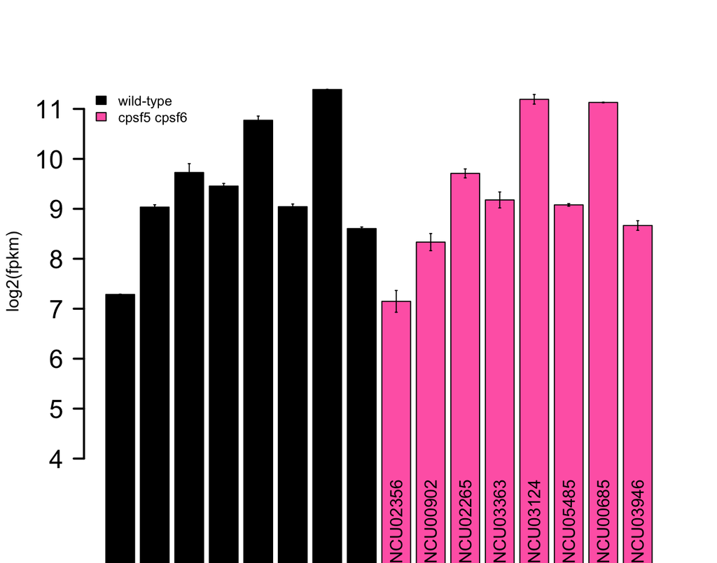

```r
all_wt <- as.matrix(output[,1:3])
all_ko <- as.matrix(output[,4:6])
all <- rbind(all_wt, all_ko)

barx <- barplot(as.numeric(all[,1]), ylim=c(4, 11.5), col=c("black", "black", "black", "black", "black", "black", "black", "black", "hotpink", "hotpink", "hotpink", "hotpink", "hotpink", "hotpink", "hotpink", "hotpink"), ylab="log2(fpkm)", cex.axis=1.5, lwd=2, las=2, names=c(core_clock, core_clock))
arrows(x0=barx, y0=as.numeric(all[,2]), y1=as.numeric(all[,3]), code=3, angle=90, length=0.01)
legend("topleft", c("wild-type","cpsf5 cpsf6"), bty="n", cex=0.8, fill=c("black", "hotpink"))
```

## Perform t-tests for differential expression

Run t-tests comparing control to delta cpsf5 cpsf6. Use log-2 transformed count values because these are normally distributed

```r
data_wt_log2 <- data_wt_log2
data_ko_log2 <- data_ko_log2
core_clock <- core_clock

output_2 <- matrix(nrow=length(core_clock), ncol=5)
for(i in 1:length(core_clock)){
  cur_gene <- core_clock[i]
  cur_wt <- as.matrix(data_wt_log2[which(row.names(data_wt_log2)==cur_gene), ])
  cur_ko <- as.matrix(data_ko_log2[which(row.names(data_ko_log2)==cur_gene), ])
  output_2[i,1] <- cur_gene
  output_2[i,2:3] <- cur_wt
  output_2[i,4:5] <- cur_ko
}
output_2 <- as.data.frame(output_2[,2:5], row.names=output_2[,1])
names(output_2) <- c("WT_log2_r1", "WT_log2_r2", "delta_log2_r1", "delta_log2_r2")

# write.table(output_2, "~/Desktop/core_clock_genes_for_ttest.txt", quote=F, sep="\t")

for(j in 1:length(core_clock)){
  cur_gene <- core_clock[j]
  cur_wt_expr <- as.numeric(as.matrix(output_2[j,1:2]))
  cur_ko_expr <- as.numeric(as.matrix(output_2[j,3:4]))
  print(paste(cur_gene,"control versus delta t-test result:", sep=" "))
  print(t.test(cur_wt_expr, cur_ko_expr))
}
```

```
## [1] "NCU02356 control versus delta t-test result:"
##
##  Welch Two Sample t-test
##
## data:  cur_wt_expr and cur_ko_expr
## t = 0.89735, df = 1.0013, p-value = 0.5343
## alternative hypothesis: true difference in means is not equal to 0
## 95 percent confidence interval:
##  -1.812683  2.089055
## sample estimates:
## mean of x mean of y
##  7.286027  7.147841
##
## [1] "NCU00902 control versus delta t-test result:"
##
##  Welch Two Sample t-test
##
## data:  cur_wt_expr and cur_ko_expr
## t = 5.5895, df = 1.1485, p-value = 0.09013
## alternative hypothesis: true difference in means is not equal to 0
## 95 percent confidence interval:
##  -0.4794096  1.8817910
## sample estimates:
## mean of x mean of y
##  9.034525  8.333335
##
## [1] "NCU02265 control versus delta t-test result:"
##
##  Welch Two Sample t-test
##
## data:  cur_wt_expr and cur_ko_expr
## t = 0.1256, df = 1.4809, p-value = 0.9149
## alternative hypothesis: true difference in means is not equal to 0
## 95 percent confidence interval:
##  -0.8408013  0.8759988
## sample estimates:
## mean of x mean of y
##  9.727109  9.709510
##
## [1] "NCU03363 control versus delta t-test result:"
```

[output cut: 48 more lines]

```
## mean of x mean of y
##  11.38819  11.12952
##
## [1] "NCU03946 control versus delta t-test result:"
##
##  Welch Two Sample t-test
##
## data:  cur_wt_expr and cur_ko_expr
## t = -0.85362, df = 1.213, p-value = 0.5289
## alternative hypothesis: true difference in means is not equal to 0
## 95 percent confidence interval:
##  -0.6692349  0.5467821
## sample estimates:
## mean of x mean of y
##  8.604839  8.666066
```